# crms_irf.ipynb

trying iterative random forests on random forest generated from both

1. binary model of prediction gene expression
2. multiclass model of predicting cell type

based on https://github.com/Yu-Group/iterative-Random-Forest/blob/master/demo/28_iRF_demo_sklearn.ipynb

and the Iteratve Random Forest (Basu paper)

TODOs

- keep reading papers

```python
# basic packages
import os, glob
import pandas as pd
import numpy as np; np.random.seed(0)
import itertools
from collections import Counter, defaultdict
import time

# machine learning packages from sklearn
from sklearn.preprocessing import MinMaxScaler #StandardScaler
from sklearn import preprocessing, metrics
from sklearn.feature_selection import VarianceThreshold
from sklearn.model_selection import train_test_split, KFold, cross_validate, cross_val_score, StratifiedKFold
from sklearn.linear_model import LogisticRegression, Lasso, LassoCV
from sklearn.naive_bayes import GaussianNB
from sklearn.svm import LinearSVC
from sklearn.ensemble import RandomForestClassifier, RandomForestRegressor, VotingClassifier, AdaBoostClassifier
from sklearn.neighbors import KNeighborsClassifier
from sklearn.neural_network import MLPClassifier
from sklearn.metrics import roc_auc_score, auc, roc_curve, plot_roc_curve, confusion_matrix, accuracy_score
from scipy import interp

# for IRF
from functools import reduce
# Needed for the scikit-learn wrapper function
import irf
from irf import (irf_utils, utils,
                 irf_jupyter_utils)
from irf.ensemble.wrf import RandomForestClassifierWithWeights
from math import ceil

# Import our custom utilities
from imp import reload


# Import tools needed for visualization
import seaborn as sns; sns.set()
import matplotlib
import matplotlib.pyplot as plt
from sklearn.tree import export_graphviz
import pydot
```

```python
# TF annotations
hoco_annon_file = 'annon/HOCOMOCOv11_core_annotation_HUMAN_mono.tsv'
hoco_annon = pd.read_table(hoco_annon_file,header=0)
hoco_annon[['motif_abbr','motif_info']]=hoco_annon['Model'].str.split("_",expand=True)
hoco_motif_to_tf = pd.Series(hoco_annon['Transcription factor'].values, index=hoco_annon.motif_abbr.values).to_dict()
tfs = list(hoco_annon['Transcription factor'])


# RNA
THRES=1
rna_tpm_file = 'rnaseq/tissue_tpm_sym.csv'
rna_df = pd.read_csv(rna_tpm_file, index_col=0,header=0)
rna_df.index = [x.upper() for x in rna_df.index.values]
all_genes = rna_df.index
tissue_diffloop_to_rna = {
    'Air':'Airway', 'Astro':'Astrocytes', 'Blad':'Bladder', 'Colon':'Colon', 'Eso':'Esophageal',
    'GDSD0':'GDSD0', 'GDSD3':'GDSD3', 'GDSD6':'GDSD6',
    'GM12878':'GM12878', 'HMEC':'HMEC', 'MC':'Melanocytes', 'Ova':'Ovarian',
    'Panc':'Pancreas', 'Pros':'Prostate', 'Renal':'Renal', 'Thy':'Thyroid', 'Uter':'Uterine'
}

def get_exp(rna_df, sym, tissue,verbose=True):
    try:
        return rna_df.loc[sym,tissue]
    except KeyError:
        if verbose:
            print(sym, 'not found')
        return 0

# loop and anchor and crms
loop_files = sorted(glob.glob('diffloop_data/bedpe_files_csvs_rna/*merged.loops.csv'))
anchor_files = sorted(glob.glob('diffloop_data/bedpe_files_csvs_rna/*merged.anchors.csv'))
crm_files = sorted(glob.glob('networks/diffgene/all_no_thres/*_crm_tissue.csv'))


tissues = []
for crm in crm_files:
    tissues.append(os.path.basename(crm).split('_')[1])
tissue_dict = dict(zip(tissues,range(len(tissues))))

# print(loop_files)
# print(anchor_files)
```

# 0. Data Wrangling

- import
- preprocess

```python
# import
data_all = pd.read_csv('networks/representations_no_tfs/data_all.csv',index_col=0,header=0)
labels_all = np.array(pd.read_csv('networks/representations_no_tfs/labels_all.csv',index_col=0,header=None))
genes_all = np.array(pd.read_csv('networks/representations_no_tfs/genes_all.csv',index_col=0,header=None))


data_all.shape, labels_all.shape,genes_all.shape
```

```
((291006, 824), (291006, 1), (291006, 1))
```

```python
# labels for problem 1: `labels_all_bin`
labels_all_bin = np.array([1 if x > THRES else 0 for x in labels_all])
```

```python
# labels for problem 2: `tissue_labels`
gene_to_num_dict = dict(zip(np.unique(genes_all),range(len(np.unique(genes_all)))))
genes_num_all = np.vectorize(gene_to_num_dict.get)(genes_all)


tissue_to_num_dict = dict(zip(tissue_dict.keys(), range(len(tissue_dict.keys()))))
tissue_df = data_all[tissue_dict.keys()].reset_index().melt('index')
tissue_df.columns = ['index','tissue','value']
tissue_df = tissue_df[tissue_df.value==1].reset_index(drop=True)
tissue_df['tissue_num'] = tissue_df.tissue.map(tissue_to_num_dict)

tissue_labels = np.array(tissue_df.tissue)
tissue_num_labels = np.array(tissue_df.tissue_num)

print(Counter(tissue_labels))
```

```
Counter({'Air': 17118, 'Astro': 17118, 'Blad': 17118, 'Colon': 17118, 'Eso': 17118, 'GDSD0': 17118, 'GDSD3': 17118, 'GDSD6': 17118, 'GM12878': 17118, 'HMEC': 17118, 'MC': 17118, 'Ova': 17118, 'Panc': 17118, 'Pros': 17118, 'Renal': 17118, 'Thy': 17118, 'Uter': 17118})
```

```python
# set up data collection, remove the tissues and uninformative columns

data_all_no_tissue = data_all

if '_loop' in data_all_no_tissue.columns:
    data_all_no_tissue.drop('_loop',axis=1,inplace=True)

for tissue in tissue_dict.keys():

    if tissue in data_all_no_tissue.columns:
        data_all_no_tissue.drop(tissue,axis=1,inplace=True)
```

```python
# data for problem 1: `data_all_norm_`
data_all_1 = data_all_no_tissue#.copy()

# make sure expression is removed
if 'log_exp' in data_all_1.columns:
    data_all_1.drop('log_exp',axis=1,inplace=True)

if 'num_atac_regions' in data_all_1.columns:
    data_all_1.drop('num_atac_regions',axis=1,inplace=True)

if 'num_loop_counts' in data_all_1.columns:
    data_all_1.drop('num_loop_counts',axis=1,inplace=True)

if 'num_loops' in data_all_1.columns:
    data_all_1.drop('num_loops',axis=1,inplace=True)


# remove zero variance columns and scale rest
selector = VarianceThreshold()
data_all_varfilt_1 = selector.fit_transform(data_all_1)
data_all_varfilt_cols_1 = data_all_1.columns[selector.get_support()]
print(data_all_1.shape, data_all_varfilt_1.shape, len(data_all_varfilt_cols_1))
scaler = MinMaxScaler()
data_all_norm_1 = scaler.fit_transform(data_all_varfilt_1)
print(data_all_varfilt_1.shape, data_all_norm_1.shape)
```

```
(291006, 803) (291006, 649) 649
(291006, 649) (291006, 649)
```

```python
# # data for problem 2: `data_all_norm_2`
# data_all_2 = data_all_no_tissue.copy()

# # keep gene expression value and the id of the gene itself
# data_all_2['log_exp'] = labels_all
# data_all_2['gene_num'] = genes_num_all

# selector = VarianceThreshold()
# data_all_varfilt_2 = selector.fit_transform(data_all_2)
# data_all_varfilt_cols_2 = data_all_2.columns[selector.get_support()]
# print(data_all_2.shape, data_all_varfilt_2.shape, len(data_all_varfilt_cols_2))
# scaler = MinMaxScaler()
# data_all_norm_2 = scaler.fit_transform(data_all_varfilt_2)
# print(data_all_varfilt_2.shape, data_all_norm_2.shape)
```

```python
save_dir = 'networks/representations_irf'
if not os.path.exists(save_dir):
    os.makedirs(save_dir)
```

# A. Problem 1: binary classification of gene expression

## A.1 split data and run RF

```python
# %%time
# # aside test % of data to get certin result

# perc_arr = [0.01, 0.025, 0.05, .1, .15, .2, .25, .5, .75, 1]
# roc_arr = []
# for perc in perc_arr:
#     num_sample = int(data_all_norm_1.shape[0]*perc)
#     random_idx = np.random.choice(range(data_all_norm_1.shape[0]),num_sample,replace=False)
#     print(perc, random_idx.shape[0], data_all_norm_1.shape[0])
#     train_features, test_features, train_labels, test_labels = train_test_split(data_all_norm_1[random_idx,:],
#                                                                             labels_all_bin[random_idx],
#                                                                             test_size = 0.25, random_state = 42)

#     model = RandomForestClassifier(n_estimators=100,#50,
#                                max_features = 'sqrt',
#                                n_jobs=-1, verbose = 0)
#     model.fit(train_features, train_labels)

#     rf_predictions = model.predict(test_features)
#     acc = accuracy_score(test_labels, rf_predictions)
#     print(acc)

#     rf_probs = model.predict_proba(test_features)[:, 1]
#     roc_value = roc_auc_score(test_labels, rf_probs)
#     print(roc_value)
#     roc_arr.append(roc_value)
```

[output not shown]

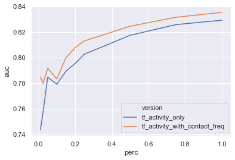

```python
# sns.lineplot(x="perc", y="roc", data= pd.DataFrame.from_dict({'perc':perc_arr, 'roc':roc_arr}, orient='columns'))

eval_df = pd.read_csv(os.path.join(save_dir, 'rf_perc_data_evaluation.csv'))
sns.lineplot(x="perc", y="auc", hue="version",data=eval_df)
```

```python
#### TESTING #####
print(data_all_norm_1.shape)
perc = .1
num_sample = int(data_all_norm_1.shape[0]*perc)
random_idx = np.random.choice(range(data_all_norm_1.shape[0]),num_sample,replace=False)
print(perc, random_idx.shape[0], data_all_norm_1.shape[0])
```

```
(291006, 649)
0.1 29100 291006
```

```python
# Problem 1 (gene exp pred binary): Split the data into training and testing sets
# train_features, test_features, train_labels, test_labels = train_test_split(data_all_norm_1, labels_all_bin,
#                                                                             test_size = 0.25, random_state = 42)

train_features, test_features, train_labels, test_labels = train_test_split(data_all_norm_1[random_idx,:],
                                                                            labels_all_bin[random_idx],
                                                                            test_size = 0.25, random_state = 42)



print('Training Features Shape:', train_features.shape)
print('Training Labels Shape:', train_labels.shape)
print('Testing Features Shape:', test_features.shape)
print('Testing Labels Shape:', test_labels.shape)
```

```
Training Features Shape: (21825, 649)
Training Labels Shape: (21825,)
Testing Features Shape: (7275, 649)
Testing Labels Shape: (7275,)
```

```python
%%time
# Create the model with 100 trees
model = RandomForestClassifier(n_estimators=100,#50,
                               max_features = 'sqrt',
                               n_jobs=-1, verbose = 0)
# Fit on training data
model.fit(train_features, train_labels)
# Actual class predictions
rf_predictions = model.predict(test_features)
```

```
CPU times: user 1min 37s, sys: 553 ms, total: 1min 37s
Wall time: 7.34 s
```

```
0.7359450171821306
[[2213 1209]
 [ 712 3141]]
0.7807471024195285
```

```
<sklearn.metrics._plot.roc_curve.RocCurveDisplay at 0x7fcdf8227110>
```

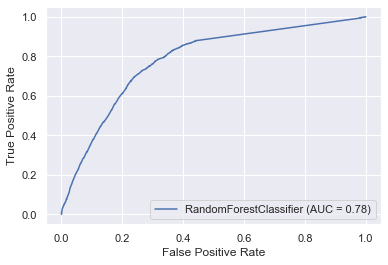

```python
# evaluation
acc = accuracy_score(test_labels, rf_predictions)
print(acc)
# Probabilities for each class
rf_probs = model.predict_proba(test_features)[:, 1]
# Calculate roc auc
print(confusion_matrix(test_labels, rf_predictions))
roc_value = roc_auc_score(test_labels, rf_probs)
print(roc_value)
plot_roc_curve(model, test_features, test_labels)
# Extract feature importances
```

## A.2: Get all Random Forest and Decision Tree Data

Extract in a single dictionary the random forest data and for all of it's decision trees This is as required for RIT purposes

```python
%%time
all_rf_tree_data = utils.get_rf_tree_data(
    rf=model, X_train=train_features, X_test=test_features, y_test=test_labels)

# all_rf_tree_data = get_rf_tree_data(
#     rf=model, X_train=train_features, X_test=test_features, y_test=test_labels)
```

```
CPU times: user 14min 6s, sys: 41.2 s, total: 14min 47s
Wall time: 14min 45s
```

## A.3: Get the RIT data and produce RITs

RIT = random interaction tree

```python
np.random.seed(12)
all_rit_tree_data = irf_utils.get_rit_tree_data(
    all_rf_tree_data=all_rf_tree_data,
    bin_class_type=1,
    M=100,
    max_depth=2,
    noisy_split=False,
    num_splits=2)
# Perform Manual CHECKS on the irf_utils
# These should be converted to unit tests and checked with nosetests -v test_irf_utils.py
```

## A.4: Plot and Evaluate Data

### List Ranked Feature Importances

```python
# Print the feature ranking (from irf)
print("Feature ranking:")

feature_importances_rank_idx = all_rf_tree_data['feature_importances_rank_idx']
feature_importances = all_rf_tree_data['feature_importances']

for f in range(train_features.shape[1]):
    print("%d. feature %s (%f)" % (f + 1
                                   , data_all_varfilt_cols_1[feature_importances_rank_idx][f]
                                   , feature_importances[feature_importances_rank_idx[f]]))
```

```
Feature ranking:
1. feature MAZ_loop (0.027273)
2. feature PATZ1_loop (0.018037)
3. feature SP1_loop (0.015276)
4. feature ZNF281_loop (0.015022)
5. feature SP3_loop (0.014357)
6. feature KLF5_loop (0.013730)
7. feature VEZF1_loop (0.013253)
8. feature SP2_loop (0.013248)
9. feature ZNF263_loop (0.011801)
10. feature SP1_anc (0.011409)
11. feature KLF3_loop (0.009784)
12. feature E2F4_loop (0.009154)
13. feature EGR1_loop (0.009107)
14. feature ZFX_loop (0.008805)
15. feature ZNF770_loop (0.008705)
16. feature KLF6_loop (0.008698)
17. feature MAZ_anc (0.008562)
18. feature KLF9_loop (0.008157)
19. feature KLF4_loop (0.008027)
20. feature ZBTB17_loop (0.007498)
21. feature ETS2_loop (0.007352)
22. feature E2F7_loop (0.006945)
23. feature SP2_anc (0.006724)
24. feature E2F6_loop (0.006622)
25. feature ETV5_loop (0.006613)
26. feature TAF1_loop (0.006499)
27. feature VEZF1_anc (0.006353)
28. feature PATZ1_anc (0.005855)
29. feature num_snp (0.005813)
30. feature THAP1_loop (0.005356)
31. feature TFDP1_loop (0.005146)
32. feature SP3_anc (0.005090)
33. feature E2F3_loop (0.004958)
34. feature NFIC_loop (0.004924)
35. feature NRF1_loop (0.004802)
36. feature WT1_loop (0.004688)
37. feature ETV4_loop (0.004653)
38. feature ETS1_loop (0.004493)
39. feature E2F1_loop (0.004423)
```

[output cut: 595 more lines]

```
635. feature ZNF549_anc (0.000016)
636. feature MYB_anc (0.000016)
637. feature LHX2_anc (0.000014)
638. feature OTX2_anc (0.000014)
639. feature ALX1_loop (0.000013)
640. feature POU3F2_anc (0.000010)
641. feature ALX1_anc (0.000010)
642. feature TFE3_anc (0.000007)
643. feature HOXB13_anc (0.000006)
644. feature MEF2C_anc (0.000005)
645. feature NR6A1_anc (0.000003)
646. feature E2F5_anc (0.000002)
647. feature FOXP2_anc (0.000001)
648. feature ZNF490_anc (0.000000)
649. feature ZNF382_loop (0.000000)
```

```python
# compare to what sklearn directly outputs
fi = pd.DataFrame({'feature': list(data_all_varfilt_cols_1),
                   'importance': model.feature_importances_}).\
                    sort_values('importance', ascending = False)

# Display
fi.head(10)
```

|  | feature | importance |
| --- | --- | --- |
| 247 | MAZ_loop | 0.027273 |
| 341 | PATZ1_loop | 0.018037 |
| 435 | SP1_loop | 0.015276 |
| 581 | ZNF281_loop | 0.015022 |
| 439 | SP3_loop | 0.014357 |
| 221 | KLF5_loop | 0.013730 |
| 523 | VEZF1_loop | 0.013253 |
| 437 | SP2_loop | 0.013248 |
| 575 | ZNF263_loop | 0.011801 |
| 434 | SP1_anc | 0.011409 |

### Plot Ranked Feature Importances

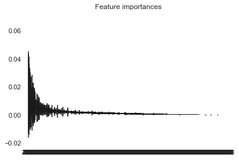

```python
# Plot the feature importances of the forest
feature_importances_std = all_rf_tree_data['feature_importances_std']

plt.title("Feature importances")
plt.bar(range(train_features.shape[1])
        , feature_importances[feature_importances_rank_idx]
        , color="r"
        , yerr = feature_importances_std[feature_importances_rank_idx], align="center")
plt.xticks(range(train_features.shape[1]), feature_importances_rank_idx)
plt.xlim([-1, train_features.shape[1]])
plt.show()
```

### Decision Tree 0 (First) - Get output

```python
# # Now plot the trees individually
# irf_jupyter_utils.draw_tree(decision_tree = model.estimators_[0])
```

### Compare to our dict of extracted data from the tree

```python
#irf_jupyter_utils.pretty_print_dict(inp_dict = all_rf_tree_data['dtree0'])
```

```python
# # Count the number of samples passing through the leaf nodes (equals size of training set)
# sum(all_rf_tree_data['dtree0']['tot_leaf_node_values'])
```

```python
#irf_jupyter_utils.pretty_print_dict(inp_dict = all_rf_tree_data['dtree0']['all_leaf_paths_features'])
```

## A.5: Run the iRF function!

Data:

#### Running the iRF is easy - single function call

All of the bootstrap, RIT complexity is covered through the key parameters passed through in the main algorithm (as listed above) This function call returns the following data:

- all RF weights
- all the K RFs that are iterated over
- all of the B bootstrap RFs that are run
- all the B*M RITs that are run on the bootstrap RFs
- the stability score

This is a lot of data returned! Will be useful when they build the interface later

```python
%%time
all_rf_weights, all_K_iter_rf_data, \
all_rf_bootstrap_output, all_rit_bootstrap_output, \
stability_score = irf_utils.run_iRF(X_train=train_features,
                                    X_test=test_features,
                                    y_train=train_labels,
                                    y_test=test_labels,
                                    K=5,
                                    rf=RandomForestClassifierWithWeights(n_estimators=50),
                                    B=30,
                                    random_state_classifier=2018,
                                    propn_n_samples=.2,
                                    bin_class_type=1,
                                    M=20,
                                    max_depth=5,
                                    noisy_split=False,
                                    num_splits=2,
                                    n_estimators_bootstrap=5)
```

```
CPU times: user 34min 19s, sys: 1min 20s, total: 35min 40s
Wall time: 35min 38s
```

THIS IS WHAT WE CARE ABOUT `stability_score`

```python
data_all_varfilt_cols_1
```

```
Index(['AHR_anc', 'AHR_loop', 'ALX1_anc', 'ALX1_loop', 'ARID5B_anc',
       'ARID5B_loop', 'ARNTL_anc', 'ARNTL_loop', 'ARNT_anc', 'ARNT_loop',
       ...
       'ZNF76_loop', 'ZNF770_anc', 'ZNF770_loop', 'ZNF816_anc', 'ZNF816_loop',
       'ZNF85_anc', 'ZNF85_loop', 'ZSCAN31_anc', 'ZSCAN31_loop', 'num_snp'],
      dtype='object', length=649)
```

```python
stability_score_names = {}
for feat_idx, score in sorted(stability_score.items(),key=lambda x:x[1],reverse=True):
    feat_names_arr = [data_all_varfilt_cols_1[int(x)] for x in feat_idx.split('_')]
    feat_names = '::'.join(feat_names_arr)
    stability_score_names[feat_names] = score
stability_df = pd.Series(stability_score_names)
stability_df.to_csv(os.path.join(save_dir, 'stability_score_names_genes_2.csv'))
stability_df
```

```
MAZ_loop                                                                                                                                                                       1.000000
MAZ_loop::SP1_anc                                                                                                                                                              0.966667
MAZ_loop::PATZ1_loop                                                                                                                                                           0.933333
MAZ_loop::SP1_loop                                                                                                                                                             0.833333
MAZ_loop::ZNF770_loop                                                                                                                                                          0.700000
                                                                                                                                                                                 ...
MAZ_loop::PATZ1_loop::SP1_anc::VEZF1_loop                                                                                                                                      0.033333
MAZ_loop::PATZ1_loop::SP1_anc::SP2_loop::WT1_loop                                                                                                                              0.033333
EGR1_loop::ELK1_anc::KLF5_loop::KLF6_anc::MAZ_anc::MAZ_loop::NRF1_anc::PATZ1_anc::PATZ1_loop::SP1_anc::TFDP1_anc::WT1_loop::ZBTB14_loop::ZNF263_anc::ZNF281_anc::ZNF770_anc    0.033333
MAZ_loop::PATZ1_loop::SP1_anc::WT1_loop                                                                                                                                        0.033333
MAZ_loop::PATZ1_loop::WT1_loop                                                                                                                                                 0.033333
Length: 1442, dtype: float64
```

### Examine the stability scores

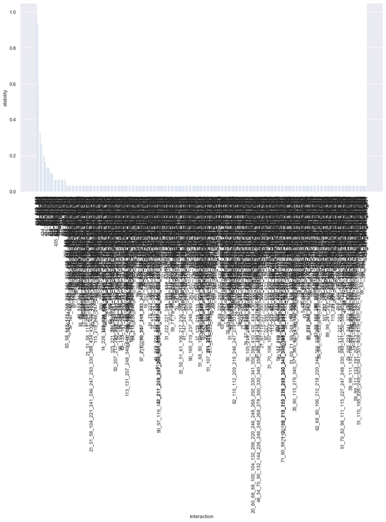

```python
irf_jupyter_utils._get_histogram(stability_score, sort = True)
```

### Examine feature importances

In particular, let us see how they change over the K iterations of random forest

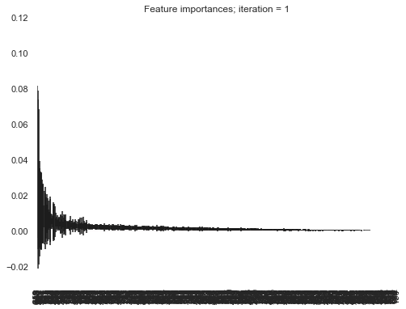

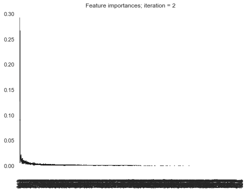

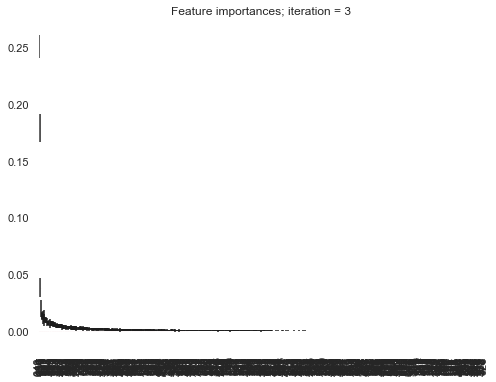

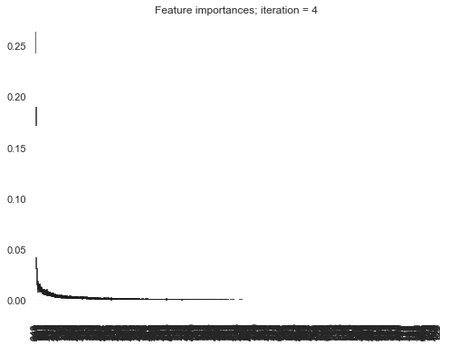

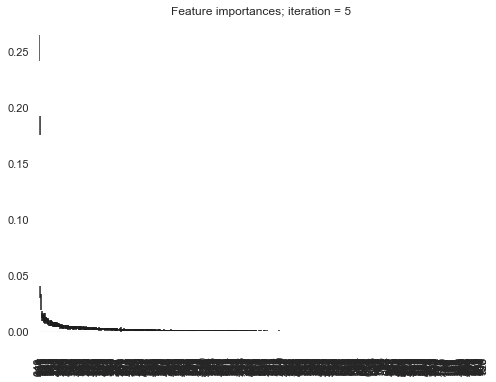

```python
for k in range(1, 6):

    iteration = "rf_iter{}".format(k)

    feature_importances_std = all_K_iter_rf_data[iteration]['feature_importances_std']
    feature_importances_rank_idx = all_K_iter_rf_data[iteration]['feature_importances_rank_idx']
    feature_importances = all_K_iter_rf_data[iteration]['feature_importances']

    plt.figure(figsize=(8, 6))
    title = "Feature importances; iteration = {}".format(k)
    plt.title(title)
    plt.bar(range(train_features.shape[1])
            , feature_importances[feature_importances_rank_idx]
            , color="r"
            , yerr = feature_importances_std[feature_importances_rank_idx], align="center")
    plt.xticks(range(train_features.shape[1]), feature_importances_rank_idx, rotation='vertical')
    plt.xlim([-1, train_features.shape[1]])
    plt.show()
```

## A.6 Explore iRF Data Further

We can look at the decision paths of the Kth RF Let's look at the final iteration RF - the key validation metrics

```python
irf_jupyter_utils.pretty_print_dict(all_K_iter_rf_data['rf_iter5']['rf_validation_metrics'])
# {   'accuracy_score': 0.9649122807017544,
#     'confusion_matrix': array([[12,  2],
#        [ 0, 43]]),
#     'f1_score': 0.9772727272727273,
#     'hamming_loss': 0.03508771929824561,
#     'log_loss': 1.2119149470996806,
#     'precision_score': 0.9555555555555556,
#     'recall_score': 1.0,
#     'zero_one_loss': 0.03508771929824561}
```

```
{   'accuracy_score': 0.7256,
    'confusion_matrix': array([[ 777,  370],
       [ 316, 1037]]),
    'f1_score': 0.7514492753623188,
    'hamming_loss': 0.2744,
    'log_loss': 9.477558583183162,
    'precision_score': 0.7370291400142146,
    'recall_score': 0.7664449371766445,
    'zero_one_loss': 0.2744}
```

Now plot the trees individually

```python
#irf_jupyter_utils.draw_tree(decision_tree = all_K_iter_rf_data['rf_iter5']['rf_obj'].estimators_[0])
```

We can get this data quite easily in a convenient format

```python
irf_jupyter_utils.pretty_print_dict(
    all_K_iter_rf_data['rf_iter5']['dtree0']['all_leaf_paths_features'])
```

[output not shown]

[output cut: 2578 more lines]

```
    array([648, 649, 434, 649, 650, 539, 246, 437, 132, 650, 436]),
    array([648, 649, 434, 649, 650, 539, 246, 437, 132, 640]),
    array([648, 649, 434, 649, 650, 539, 246, 437, 132, 640]),
    array([648, 649, 434, 649, 650, 539, 246, 437]),
    array([648, 649, 434, 649, 650, 539, 220, 388, 247]),
    array([648, 649, 434, 649, 650, 539, 220, 388, 247, 439, 119, 439]),
    array([648, 649, 434, 649, 650, 539, 220, 388, 247, 439, 119, 439]),
    array([648, 649, 434, 649, 650, 539, 220, 388, 247, 439, 119, 649]),
    array([648, 649, 434, 649, 650, 539, 220, 388, 247, 439, 119, 649, 528]),
    array([648, 649, 434, 649, 650, 539, 220, 388, 247, 439, 119, 649, 528]),
    array([648, 649, 434, 649, 650, 539, 220, 388, 247, 439]),
    array([648, 649, 434, 649, 650, 539, 220, 388]),
    array([648, 649, 434, 649, 650, 539, 220, 523, 341]),
    array([648, 649, 434, 649, 650, 539, 220, 523, 341]),
    array([648, 649, 434, 649, 650, 539, 220, 523])]
```

Notes comparing above combination against decision paths

In fact - we can go further and plot some interesting data from the Decision Trees. This can help us understand variable interactions better

```python
irf_jupyter_utils.pretty_print_dict(
    all_K_iter_rf_data['rf_iter5']['dtree0']['all_leaf_node_values'])
```

[output not shown]

[output cut: 1206 more lines]

```
    array([[1, 0]]),
    array([[0, 6]]),
    array([[4, 0]]),
    array([[1, 0]]),
    array([[1, 0]]),
    array([[1, 0]]),
    array([[ 0, 14]]),
    array([[3, 0]]),
    array([[0, 3]]),
    array([[1, 0]]),
    array([[ 0, 36]]),
    array([[2, 0]]),
    array([[0, 1]]),
    array([[11,  0]]),
    array([[0, 9]])]
```

We can also look at the frequency that a feature appears along a decision path

```python
irf_jupyter_utils._hist_features(all_K_iter_rf_data['rf_iter5'], n_estimators = 20, \
                         title = 'Frequency of features along decision paths : iteration = 5')
```

[output not shown]

### Run some Sanity Checks

Run iRF for just 1 iteration - should be the uniform sampling version This is just a sanity check: the feature importances from iRF after 1 iteration should match the feature importance from running a standard RF

```python
all_K_iter_rf_data.keys()
print(all_K_iter_rf_data['rf_iter1']['feature_importances'])
```

[output not shown]

Compare to the original single fitted random forest

```python
# rf = RandomForestClassifierWithWeights(n_estimators=20, random_state=2018)
# rf.fit(X=X_train, y=y_train)
print(model.feature_importances_)
```

[output not shown]

```python
# Problem 2 (tissue): Split the data into training and testing sets
train_features_2, test_features_2, train_labels_2, test_labels_2 = train_test_split(data_all_norm_2, tissue_labels,
                                                                            test_size = 0.25, random_state = 42)


print('Training Features Shape:', train_features_1.shape)
print('Training Labels Shape:', train_labels_1.shape)
print('Testing Features Shape:', test_features_1.shape)
print('Testing Labels Shape:', test_labels_1.shape)
```

[output not shown]